# Project: Investigate a Dataset - [TMDb movie data]

- Introduction
- Data Wrangling
- Exploratory Data Analysis
- Conclusions

## Introduction

### Dataset Description

> The dataset contains about 10867 movies collected from the movie database. the details collected includes the ID, imdb id, revenue generated, movie popularity, genre, the revenue generated,the original title, the casts, the home page, the director, the tagline, the keywords, the overview, the runtime, the production company, the release date, the vote count,the vote average, the release year, the budget adj and the revenue adj.

### Question(s) for Analysis

> 1. The most popular genre.
>    1. The year with the highest number of movies produced.
>    2. Movies with highest generated revenue

```python
import numpy as np
import pandas as pd
import matplotlib.pyplot as plt
import seaborn as sns
% matplotlib inline
```

```python
# Upgrade pandas to use dataframe.explode() function.
!pip install --upgrade pandas==0.25.0
```

[output not shown]

## Data Wrangling

>

### General Properties

```python
df=pd.read_csv('tmdb-movies.csv')
df.head
```

```
<bound method NDFrame.head of            id    imdb_id  popularity     budget     revenue  \
0      135397  tt0369610   32.985763  150000000  1513528810
1       76341  tt1392190   28.419936  150000000   378436354
2      262500  tt2908446   13.112507  110000000   295238201
3      140607  tt2488496   11.173104  200000000  2068178225
4      168259  tt2820852    9.335014  190000000  1506249360
5      281957  tt1663202    9.110700  135000000   532950503
6       87101  tt1340138    8.654359  155000000   440603537
7      286217  tt3659388    7.667400  108000000   595380321
8      211672  tt2293640    7.404165   74000000  1156730962
9      150540  tt2096673    6.326804  175000000   853708609
10     206647  tt2379713    6.200282  245000000   880674609
11      76757  tt1617661    6.189369  176000003   183987723
12     264660  tt0470752    6.118847   15000000    36869414
13     257344  tt2120120    5.984995   88000000   243637091
```

[output cut: 616 more lines]

```python
df.shape
```

```
(10866, 21)
```

the dimension of the dataframe is (10866,21)

```python
## datatype of each column
## objects are also strings in pandas

df.dtypes
```

```
id                        int64
imdb_id                  object
popularity              float64
budget                    int64
revenue                   int64
original_title           object
cast                     object
homepage                 object
director                 object
tagline                  object
keywords                 object
overview                 object
runtime                   int64
genres                   object
production_companies     object
release_date             object
vote_count                int64
vote_average            float64
release_year              int64
budget_adj              float64
revenue_adj             float64
dtype: object
```

```python
## brief summary of dataframe including the null value present in it

df.info()
```

```
<class 'pandas.core.frame.DataFrame'>
RangeIndex: 10866 entries, 0 to 10865
Data columns (total 21 columns):
id                      10866 non-null int64
imdb_id                 10856 non-null object
popularity              10866 non-null float64
budget                  10866 non-null int64
revenue                 10866 non-null int64
original_title          10866 non-null object
cast                    10790 non-null object
homepage                2936 non-null object
director                10822 non-null object
tagline                 8042 non-null object
keywords                9373 non-null object
overview                10862 non-null object
runtime                 10866 non-null int64
genres                  10843 non-null object
production_companies    9836 non-null object
release_date            10866 non-null object
vote_count              10866 non-null int64
vote_average            10866 non-null float64
release_year            10866 non-null int64
budget_adj              10866 non-null float64
revenue_adj             10866 non-null float64
dtypes: float64(4), int64(6), object(11)
memory usage: 1.7+ MB
```

```python
## the numbers of unique values present in each column

df.nunique()
```

```
id                      10865
imdb_id                 10855
popularity              10814
budget                    557
revenue                  4702
original_title          10571
cast                    10719
homepage                 2896
director                 5067
tagline                  7997
keywords                 8804
overview                10847
runtime                   247
genres                   2039
production_companies     7445
release_date             5909
vote_count               1289
vote_average               72
release_year               56
budget_adj               2614
revenue_adj              4840
dtype: int64
```

```python
## brief statistical description of each column

df.describe()
```

|  | id | popularity | budget | revenue | runtime | vote_count | vote_average | release_year | budget_adj | revenue_adj |
| --- | --- | --- | --- | --- | --- | --- | --- | --- | --- | --- |
| count | 10866.000000 | 10866.000000 | 1.086600e+04 | 1.086600e+04 | 10866.000000 | 10866.000000 | 10866.000000 | 10866.000000 | 1.086600e+04 | 1.086600e+04 |
| mean | 66064.177434 | 0.646441 | 1.462570e+07 | 3.982332e+07 | 102.070863 | 217.389748 | 5.974922 | 2001.322658 | 1.755104e+07 | 5.136436e+07 |
| std | 92130.136561 | 1.000185 | 3.091321e+07 | 1.170035e+08 | 31.381405 | 575.619058 | 0.935142 | 12.812941 | 3.430616e+07 | 1.446325e+08 |
| min | 5.000000 | 0.000065 | 0.000000e+00 | 0.000000e+00 | 0.000000 | 10.000000 | 1.500000 | 1960.000000 | 0.000000e+00 | 0.000000e+00 |
| 25% | 10596.250000 | 0.207583 | 0.000000e+00 | 0.000000e+00 | 90.000000 | 17.000000 | 5.400000 | 1995.000000 | 0.000000e+00 | 0.000000e+00 |
| 50% | 20669.000000 | 0.383856 | 0.000000e+00 | 0.000000e+00 | 99.000000 | 38.000000 | 6.000000 | 2006.000000 | 0.000000e+00 | 0.000000e+00 |
| 75% | 75610.000000 | 0.713817 | 1.500000e+07 | 2.400000e+07 | 111.000000 | 145.750000 | 6.600000 | 2011.000000 | 2.085325e+07 | 3.369710e+07 |
| max | 417859.000000 | 32.985763 | 4.250000e+08 | 2.781506e+09 | 900.000000 | 9767.000000 | 9.200000 | 2015.000000 | 4.250000e+08 | 2.827124e+09 |

### Data Cleaning

```python
## some key colums i will need

np.r_[0,1,3,4,5,13,18]
df_new=df.iloc[:,np.r_[0,1,3,4,5,13,18]]
df_new.head()
```

|  | id | imdb_id | budget | revenue | original_title | genres | release_year |
| --- | --- | --- | --- | --- | --- | --- | --- |
| 0 | 135397 | tt0369610 | 150000000 | 1513528810 | Jurassic World | Action\|Adventure\|Science Fiction\|Thriller | 2015 |
| 1 | 76341 | tt1392190 | 150000000 | 378436354 | Mad Max: Fury Road | Action\|Adventure\|Science Fiction\|Thriller | 2015 |
| 2 | 262500 | tt2908446 | 110000000 | 295238201 | Insurgent | Adventure\|Science Fiction\|Thriller | 2015 |
| 3 | 140607 | tt2488496 | 200000000 | 2068178225 | Star Wars: The Force Awakens | Action\|Adventure\|Science Fiction\|Fantasy | 2015 |
| 4 | 168259 | tt2820852 | 190000000 | 1506249360 | Furious 7 | Action\|Crime\|Thriller | 2015 |

```python
## since my questions focuses on df_new, i will be working with it for the remaining part of this project. this will make dropping of columns irrelevant.

df_new.head()
```

|  | id | imdb_id | budget | revenue | original_title | genres | release_year |
| --- | --- | --- | --- | --- | --- | --- | --- |
| 0 | 135397 | tt0369610 | 150000000 | 1513528810 | Jurassic World | Action\|Adventure\|Science Fiction\|Thriller | 2015 |
| 1 | 76341 | tt1392190 | 150000000 | 378436354 | Mad Max: Fury Road | Action\|Adventure\|Science Fiction\|Thriller | 2015 |
| 2 | 262500 | tt2908446 | 110000000 | 295238201 | Insurgent | Adventure\|Science Fiction\|Thriller | 2015 |
| 3 | 140607 | tt2488496 | 200000000 | 2068178225 | Star Wars: The Force Awakens | Action\|Adventure\|Science Fiction\|Fantasy | 2015 |
| 4 | 168259 | tt2820852 | 190000000 | 1506249360 | Furious 7 | Action\|Crime\|Thriller | 2015 |

```python
df_new.info()
```

```
<class 'pandas.core.frame.DataFrame'>
RangeIndex: 10866 entries, 0 to 10865
Data columns (total 7 columns):
id                10866 non-null int64
imdb_id           10856 non-null object
budget            10866 non-null int64
revenue           10866 non-null int64
original_title    10866 non-null object
genres            10843 non-null object
release_year      10866 non-null int64
dtypes: int64(4), object(3)
memory usage: 594.3+ KB
```

```python
## in order to remove duplicates, i introduce the remove duplicate syntax
## i first check using the duplicated function to see if i could easily identify any

df_new.duplicated()
```

```
0        False
1        False
2        False
3        False
4        False
5        False
6        False
7        False
8        False
9        False
10       False
11       False
12       False
13       False
14       False
```

[output cut: 47 more lines]

```python
## since i couldn't , i introduced the drop_duplicate function to remove any automatically to be very sure

df_new.drop_duplicates()
```

|  | id | imdb_id | budget | revenue | original_title | genres | release_year |
| --- | --- | --- | --- | --- | --- | --- | --- |
| 0 | 135397 | tt0369610 | 150000000 | 1513528810 | Jurassic World | Action\|Adventure\|Science Fiction\|Thriller | 2015 |
| 1 | 76341 | tt1392190 | 150000000 | 378436354 | Mad Max: Fury Road | Action\|Adventure\|Science Fiction\|Thriller | 2015 |
| 2 | 262500 | tt2908446 | 110000000 | 295238201 | Insurgent | Adventure\|Science Fiction\|Thriller | 2015 |
| 3 | 140607 | tt2488496 | 200000000 | 2068178225 | Star Wars: The Force Awakens | Action\|Adventure\|Science Fiction\|Fantasy | 2015 |
| 4 | 168259 | tt2820852 | 190000000 | 1506249360 | Furious 7 | Action\|Crime\|Thriller | 2015 |
| 5 | 281957 | tt1663202 | 135000000 | 532950503 | The Revenant | Western\|Drama\|Adventure\|Thriller | 2015 |
| 6 | 87101 | tt1340138 | 155000000 | 440603537 | Terminator Genisys | Science Fiction\|Action\|Thriller\|Adventure | 2015 |
| 7 | 286217 | tt3659388 | 108000000 | 595380321 | The Martian | Drama\|Adventure\|Science Fiction | 2015 |
| 8 | 211672 | tt2293640 | 74000000 | 1156730962 | Minions | Family\|Animation\|Adventure\|Comedy | 2015 |
| 9 | 150540 | tt2096673 | 175000000 | 853708609 | Inside Out | Comedy\|Animation\|Family | 2015 |
| 10 | 206647 | tt2379713 | 245000000 | 880674609 | Spectre | Action\|Adventure\|Crime | 2015 |
| 11 | 76757 | tt1617661 | 176000003 | 183987723 | Jupiter Ascending | Science Fiction\|Fantasy\|Action\|Adventure | 2015 |
| 12 | 264660 | tt0470752 | 15000000 | 36869414 | Ex Machina | Drama\|Science Fiction | 2015 |
| 13 | 257344 | tt2120120 | 88000000 | 243637091 | Pixels | Action\|Comedy\|Science Fiction | 2015 |
| 14 | 99861 | tt2395427 | 280000000 | 1405035767 | Avengers: Age of Ultron | Action\|Adventure\|Science Fiction | 2015 |
| 15 | 273248 | tt3460252 | 44000000 | 155760117 | The Hateful Eight | Crime\|Drama\|Mystery\|Western | 2015 |
| 16 | 260346 | tt2446042 | 48000000 | 325771424 | Taken 3 | Crime\|Action\|Thriller | 2015 |
| 17 | 102899 | tt0478970 | 130000000 | 518602163 | Ant-Man | Science Fiction\|Action\|Adventure | 2015 |
| 18 | 150689 | tt1661199 | 95000000 | 542351353 | Cinderella | Romance\|Fantasy\|Family\|Drama | 2015 |
| 19 | 131634 | tt1951266 | 160000000 | 650523427 | The Hunger Games: Mockingjay - Part 2 | War\|Adventure\|Science Fiction | 2015 |
| 20 | 158852 | tt1964418 | 190000000 | 209035668 | Tomorrowland | Action\|Family\|Science Fiction\|Adventure\|Mystery | 2015 |
| 21 | 307081 | tt1798684 | 30000000 | 91709827 | Southpaw | Action\|Drama | 2015 |
| 22 | 254128 | tt2126355 | 110000000 | 470490832 | San Andreas | Action\|Drama\|Thriller | 2015 |
| 23 | 216015 | tt2322441 | 40000000 | 569651467 | Fifty Shades of Grey | Drama\|Romance | 2015 |
| 24 | 318846 | tt1596363 | 28000000 | 133346506 | The Big Short | Comedy\|Drama | 2015 |
| 25 | 177677 | tt2381249 | 150000000 | 682330139 | Mission: Impossible - Rogue Nation | Action | 2015 |
| 26 | 214756 | tt2637276 | 68000000 | 215863606 | Ted 2 | Comedy | 2015 |
| 27 | 207703 | tt2802144 | 81000000 | 403802136 | Kingsman: The Secret Service | Crime\|Comedy\|Action\|Adventure | 2015 |
| 28 | 314365 | tt1895587 | 20000000 | 88346473 | Spotlight | Drama\|Thriller\|History | 2015 |
| 29 | 294254 | tt4046784 | 61000000 | 311256926 | Maze Runner: The Scorch Trials | Action\|Science Fiction\|Thriller | 2015 |
| ... | ... | ... | ... | ... | ... | ... | ... |
| 10836 | 38720 | tt0061170 | 0 | 0 | Walk Don't Run | Comedy\|Romance | 1966 |
| 10837 | 19728 | tt0060177 | 0 | 0 | The Blue Max | War\|Action\|Adventure\|Drama | 1966 |
| 10838 | 22383 | tt0060862 | 0 | 0 | The Professionals | Action\|Adventure\|Western | 1966 |
| 10839 | 13353 | tt0060550 | 0 | 0 | It's the Great Pumpkin, Charlie Brown | Family\|Animation | 1966 |
| 10840 | 34388 | tt0060437 | 0 | 0 | Funeral in Berlin | Thriller | 1966 |
| 10841 | 42701 | tt0062262 | 75000 | 0 | The Shooting | Western | 1966 |
| 10842 | 36540 | tt0061199 | 0 | 0 | Winnie the Pooh and the Honey Tree | Animation\|Family | 1966 |
| 10843 | 29710 | tt0060588 | 0 | 0 | Khartoum | Adventure\|Drama\|War\|History\|Action | 1966 |
| 10844 | 23728 | tt0059557 | 0 | 0 | Our Man Flint | Adventure\|Comedy\|Fantasy\|Science Fiction | 1966 |
| 10845 | 5065 | tt0059014 | 0 | 0 | Carry On Cowboy | Comedy\|Western | 1966 |
| 10846 | 17102 | tt0059127 | 0 | 0 | Dracula: Prince of Darkness | Horror | 1966 |
| 10847 | 28763 | tt0060548 | 0 | 0 | Island of Terror | Science Fiction\|Horror | 1966 |
| 10848 | 2161 | tt0060397 | 5115000 | 12000000 | Fantastic Voyage | Adventure\|Science Fiction | 1966 |
| 10849 | 28270 | tt0060445 | 0 | 0 | Gambit | Action\|Comedy\|Crime | 1966 |
| 10850 | 26268 | tt0060490 | 0 | 0 | Harper | Action\|Drama\|Thriller\|Crime\|Mystery | 1966 |
| 10851 | 15347 | tt0060182 | 0 | 0 | Born Free | Adventure\|Drama\|Action\|Family\|Foreign | 1966 |
| 10852 | 37301 | tt0060165 | 0 | 0 | A Big Hand for the Little Lady | Western | 1966 |
| 10853 | 15598 | tt0060086 | 0 | 0 | Alfie | Comedy\|Drama\|Romance | 1966 |
| 10854 | 31602 | tt0060232 | 0 | 0 | The Chase | Thriller\|Drama\|Crime | 1966 |
| 10855 | 13343 | tt0059221 | 700000 | 0 | The Ghost & Mr. Chicken | Comedy\|Family\|Mystery\|Romance | 1966 |
| 10856 | 20277 | tt0061135 | 0 | 0 | The Ugly Dachshund | Comedy\|Drama\|Family | 1966 |
| 10857 | 5921 | tt0060748 | 0 | 0 | Nevada Smith | Action\|Western | 1966 |
| 10858 | 31918 | tt0060921 | 0 | 0 | The Russians Are Coming, The Russians Are Coming | Comedy\|War | 1966 |
| 10859 | 20620 | tt0060955 | 0 | 0 | Seconds | Mystery\|Science Fiction\|Thriller\|Drama | 1966 |
| 10860 | 5060 | tt0060214 | 0 | 0 | Carry On Screaming! | Comedy | 1966 |
| 10861 | 21 | tt0060371 | 0 | 0 | The Endless Summer | Documentary | 1966 |
| 10862 | 20379 | tt0060472 | 0 | 0 | Grand Prix | Action\|Adventure\|Drama | 1966 |
| 10863 | 39768 | tt0060161 | 0 | 0 | Beregis Avtomobilya | Mystery\|Comedy | 1966 |
| 10864 | 21449 | tt0061177 | 0 | 0 | What's Up, Tiger Lily? | Action\|Comedy | 1966 |
| 10865 | 22293 | tt0060666 | 19000 | 0 | Manos: The Hands of Fate | Horror | 1966 |

10865 rows × 7 columns

```python
## i observed that the dataframe contained many zeros,especially the revenue and budget part, replacing them with their mean will make the figures of the dataset incorrect hence making my work not reliable so i choose to instead remove them totally from the dataset.

df_new1=df_new[df_new.revenue!=0]
df_new1=df_new1[df_new1.budget!=0]
df_new1.tail(10)
```

|  | id | imdb_id | budget | revenue | original_title | genres | release_year |
| --- | --- | --- | --- | --- | --- | --- | --- |
| 10779 | 9584 | tt0077369 | 12000000 | 22765081 | Convoy | Action\|Comedy\|Drama | 1978 |
| 10780 | 11850 | tt0077745 | 3500000 | 24046533 | Invasion of the Body Snatchers | Horror\|Thriller\|Science Fiction\|Mystery | 1978 |
| 10788 | 24961 | tt0078504 | 24000000 | 21049053 | The Wiz | Adventure\|Family\|Fantasy\|Music\|Science Fiction | 1978 |
| 10791 | 10766 | tt0077394 | 6800000 | 26518355 | Damien: Omen II | Action\|Drama\|Horror\|Thriller | 1978 |
| 10793 | 11837 | tt0078480 | 1000000 | 3713768 | Watership Down | Adventure\|Animation\|Drama | 1978 |
| 10822 | 396 | tt0061184 | 7500000 | 33736689 | Who's Afraid of Virginia Woolf? | Drama | 1966 |
| 10828 | 5780 | tt0061107 | 3000000 | 13000000 | Torn Curtain | Mystery\|Thriller | 1966 |
| 10829 | 6644 | tt0061619 | 4653000 | 6000000 | El Dorado | Action\|Western | 1966 |
| 10835 | 5923 | tt0060934 | 12000000 | 20000000 | The Sand Pebbles | Action\|Adventure\|Drama\|War\|Romance | 1966 |
| 10848 | 2161 | tt0060397 | 5115000 | 12000000 | Fantastic Voyage | Adventure\|Science Fiction | 1966 |

### For the data cleaning process

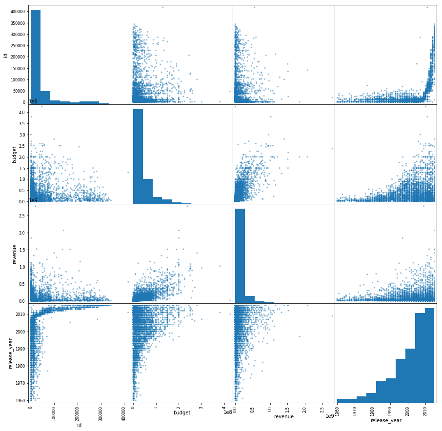

```python
pd.plotting.scatter_matrix(df_new1, figsize=(15,15));
```

## Exploratory Data Analysis

### Research Question 1 (most popular genre in the dataset)

```python
## first i will like to group the data by year and sort it out in descending order and get data for top 10 only naming it y

n_popular=df_new1.groupby("genres")["id"].count().sort_values(ascending=False)
y=n_popular.head(10)
```

```python
y.head()
```

```
genres
Drama                   245
Comedy                  233
Drama|Romance           107
Comedy|Romance          104
Comedy|Drama|Romance     91
Name: id, dtype: int64
```

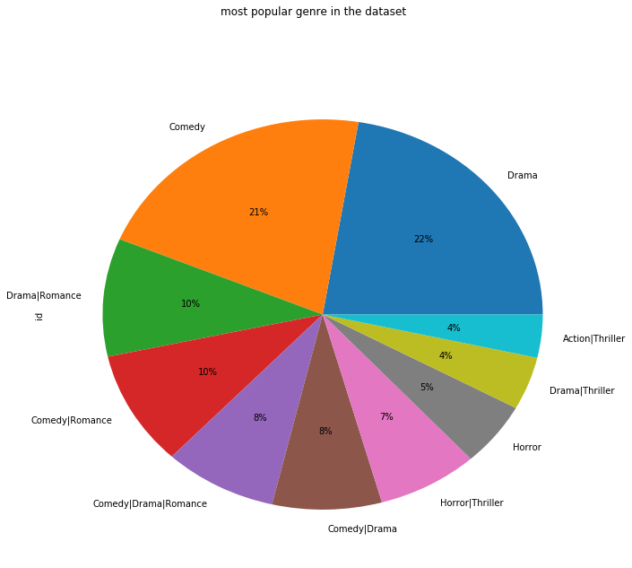

```python
## then i plot a pie chart to display the information visually

plot=y.plot.pie(subplots=True,figsize=(11,10), title='most popular genre in the dataset', autopct='%1.0f%%')
```

from the above Chart, we can see that **Drama** is the most popular genre closely followed by **Comedy**

### Research Question 2 (The Year in which the highest movies was produced)

```python
## i grouped the release year in descending order and i took out the top 10

n_popular1=df_new1.groupby("release_year")["id"].count().sort_values(ascending=False)
z=n_popular1.head(10)
```

```python
z.head()
```

```
release_year
2011    199
2013    180
2010    179
2009    174
2006    169
Name: id, dtype: int64
```

```
Text(0.5,1,'The Year in which the highest movies was produced')
```

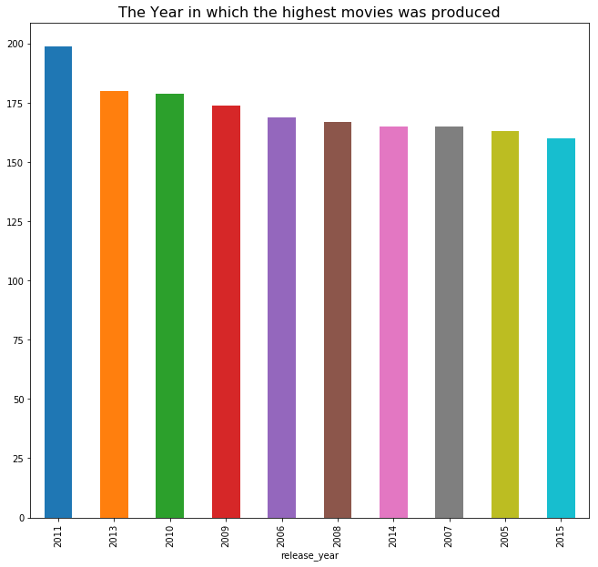

```python
## i plot a bar chart for the data cut out

plot=z.plot.bar(subplots=True,figsize=(11,10))
plt.title('The Year in which the highest movies was produced', fontsize=16)
```

from our findings, it is clear that the year 2011 has more movie produced followed by 2013

### Research Question 3 (Movies with highest generated revenue)

```python
## first, i selected the column with revenue and original title name

np.r_[4,3]
high_rev=df_new1.iloc[:,np.r_[4,3]]
high_rev.head()
```

|  | original_title | revenue |
| --- | --- | --- |
| 0 | Jurassic World | 1513528810 |
| 1 | Mad Max: Fury Road | 378436354 |
| 2 | Insurgent | 295238201 |
| 3 | Star Wars: The Force Awakens | 2068178225 |
| 4 | Furious 7 | 1506249360 |

```python
## sort for the title with the highest revenue

j=high_rev.sort_values(by=['revenue','original_title'],ascending=False)
h=j.head(10)
```

```python
h.head(10)
```

|  | original_title | revenue |
| --- | --- | --- |
| 1386 | Avatar | 2781505847 |
| 3 | Star Wars: The Force Awakens | 2068178225 |
| 5231 | Titanic | 1845034188 |
| 4361 | The Avengers | 1519557910 |
| 0 | Jurassic World | 1513528810 |
| 4 | Furious 7 | 1506249360 |
| 14 | Avengers: Age of Ultron | 1405035767 |
| 3374 | Harry Potter and the Deathly Hallows: Part 2 | 1327817822 |
| 5422 | Frozen | 1274219009 |
| 5425 | Iron Man 3 | 1215439994 |

```python
## i dropped the index to stop it from interfering in the graph

h.reset_index(drop=True, inplace=True)
h.head()
```

|  | original_title | revenue |
| --- | --- | --- |
| 0 | Avatar | 2781505847 |
| 1 | Star Wars: The Force Awakens | 2068178225 |
| 2 | Titanic | 1845034188 |
| 3 | The Avengers | 1519557910 |
| 4 | Jurassic World | 1513528810 |

```
<function matplotlib.pyplot.show(*args, **kw)>
```

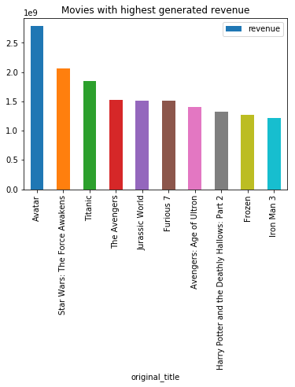

```python
h.plot(x='original_title', y='revenue', kind='bar', title='Movies with highest generated revenue')
plt.show
```

from the above we can clearly see that Avatar is the movie with the highest generated revenue

## Conclusions

key steps

1. i started with an introduction i started the project by importing pandas, numpy and matplotlib
2. i updated the pandas
3. i observed the data usind functions like info, describe, unique e.t.c . i then proceed to find potential questions which i stated at the top
4. i then cleaned the data using functions like remove duplicates, drop e.t.c
5. i then answered the questions stated at the top with the clean data accompanied with different graph for visualisation and key comment about my process
6. i wrote my conclusions, limitations and references

Question aske

1. My first question was finding 'the most popular genre' i was able to find out that Drama is the most popular genre closely followed by comedy. i was able to plot a pie chart to see the correlation visually.
2. My second question was finding "the year in which the most movie was produced" i was able to discover that more movies was produced in 2011 followed closely by 2013. i plot a bar chart to that regard
3. finally, i looked for the 'Movies with highest generated revenue'. i discovered that Avatar was the movie with the highest generated revenue. i plot a bar chart to that regard.

## Limitation

1. the revenue and budget column was full of zero values.

## References

1. geekforgeek
2. datatofish.com
3. w3school.com
4. slackoverflow.com

```python
from subprocess import call
call(['python', '-m', 'nbconvert', 'Investigate_a_Dataset.ipynb'])
```